# Compound Activity analysis

SL Mondragón-González

Summer 2024

# I. Introduction

This R Notebook is dedicated to the analysis of experimental data obtained from a series of experiments designed to evaluate the effects of various DREADD compounds administered by injections at different doses over time on the activity levels of test subjects. The subjects’ activity metrics were derived from video recordings by processing the body center’s instantaneous speed. These metrics are analyzed to assess the potential impacts of the compounds, focusing on key measurements.

## Study design

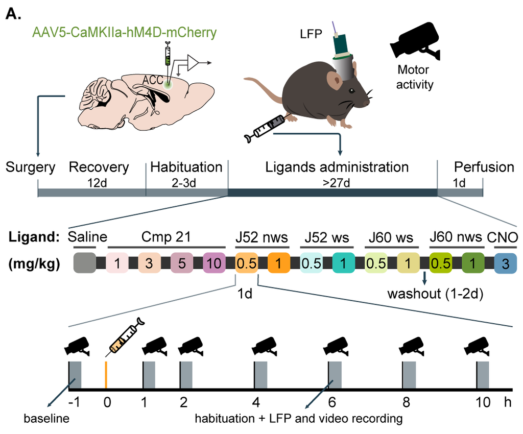

**Subjects:** 4 subjects.

     **Experiments done**

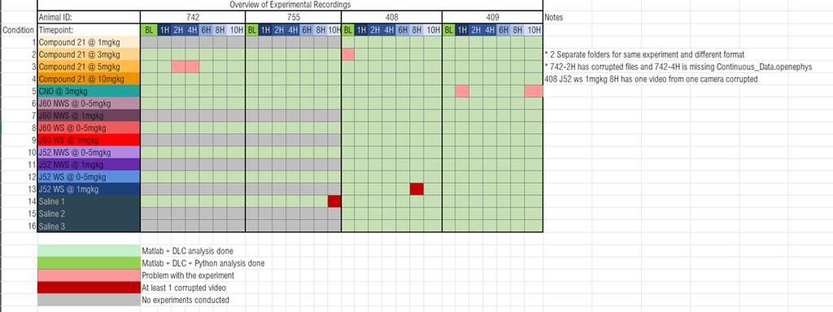

## Objectives

The primary objectives of this analysis are:

1. **Quantify the Effects of Compounds and Doses:** Determine whether the different compounds and their doses significantly impact certain activity metrics, compared against the saline control.
2. **Assess Dose-Response Relationships:** Explore how different doses influence the observed effects, and whether there is an interaction between compound type and dose.
3. **Time-Dependent Changes:** Analyze how activity metrics evolve over time post-injection to identify any time-dependent effects of the compounds and how these compare to the saline injection.
4. **Control for Baseline Activity:** Treat baseline activity as a covariate in the model to control for individual differences in normal activity levels and assess how post-injection effects differ from baseline.

# II. Data preparation

## 1. Load and check data structure

|  | vars | n | mean | sd | median | trimmed | mad | min | max | range | skew | kurtosis | se |
| --- | --- | --- | --- | --- | --- | --- | --- | --- | --- | --- | --- | --- | --- |
| High.activity.percentage | 1 | 327 | 25.55 | 5.32 | 24.51 | 25.29 | 5.41 | 10.83 | 42.23 | 31.40 | 0.43 | -0.15 | 0.29 |
| Low.activity.percentage | 2 | 327 | 73.60 | 5.45 | 74.45 | 73.87 | 5.34 | 56.85 | 89.17 | 32.32 | -0.42 | -0.08 | 0.30 |
| Occlusion.percentage | 3 | 327 | 0.85 | 1.54 | 0.00 | 0.54 | 0.00 | 0.00 | 14.75 | 14.75 | 3.74 | 24.20 | 0.08 |
| Mean | 4 | 327 | 18.99 | 9.46 | 17.79 | 18.23 | 9.49 | 2.51 | 51.49 | 48.98 | 0.79 | 0.64 | 0.52 |
| Std.deviation | 5 | 327 | 22.60 | 11.61 | 20.97 | 21.75 | 12.50 | 1.33 | 71.47 | 70.14 | 0.69 | 0.31 | 0.64 |
| ADR.Low.High.Occ | 6 | 327 | 2.96 | 0.86 | 2.91 | 2.90 | 0.80 | 1.32 | 8.23 | 6.91 | 1.11 | 3.87 | 0.05 |
| ADR.Low.High | 7 | 327 | 3.05 | 0.87 | 3.03 | 3.00 | 0.85 | 1.37 | 8.23 | 6.86 | 1.01 | 3.28 | 0.05 |
| skewness_low | 8 | 327 | 0.00 | 0.19 | 0.00 | -0.01 | 0.16 | -0.56 | 0.65 | 1.21 | 0.17 | 0.81 | 0.01 |
| skewness_high | 9 | 327 | -0.02 | 0.53 | 0.04 | 0.00 | 0.44 | -1.78 | 1.84 | 3.62 | -0.40 | 1.03 | 0.03 |
| normalized.entropy | 10 | 327 | 0.38 | 0.05 | 0.37 | 0.37 | 0.04 | 0.21 | 0.55 | 0.34 | 0.39 | 0.56 | 0.00 |

## 2. Exploratory Data Analysis (EDA)

Assessing the distribution of activity metrics across different compounds, doses, and time points.

#### 2.1 Box plots for all raw data (dependent variables)

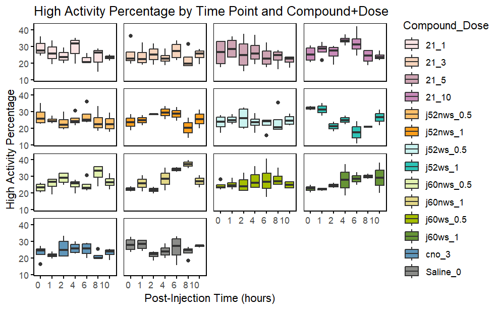

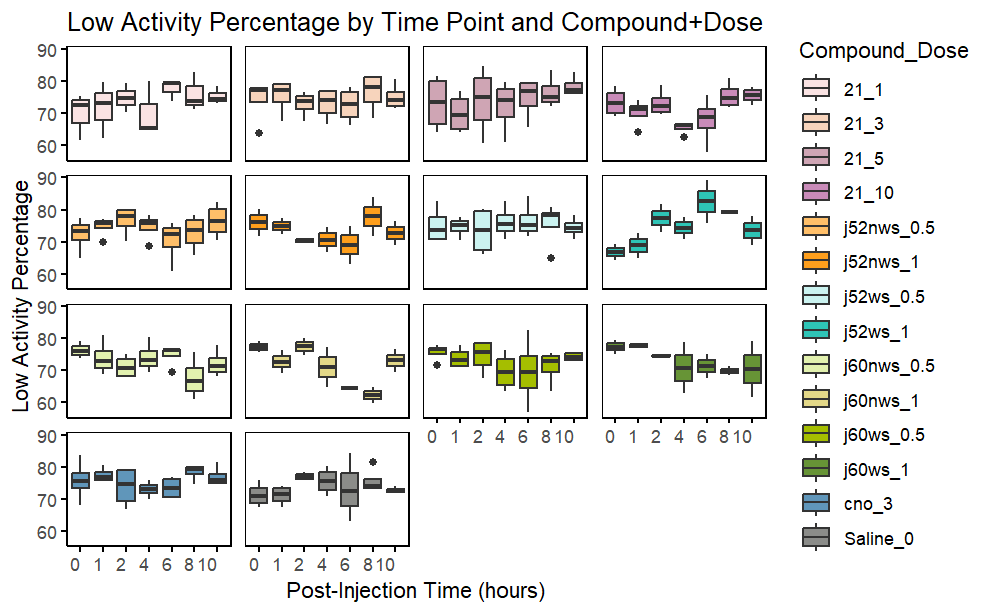

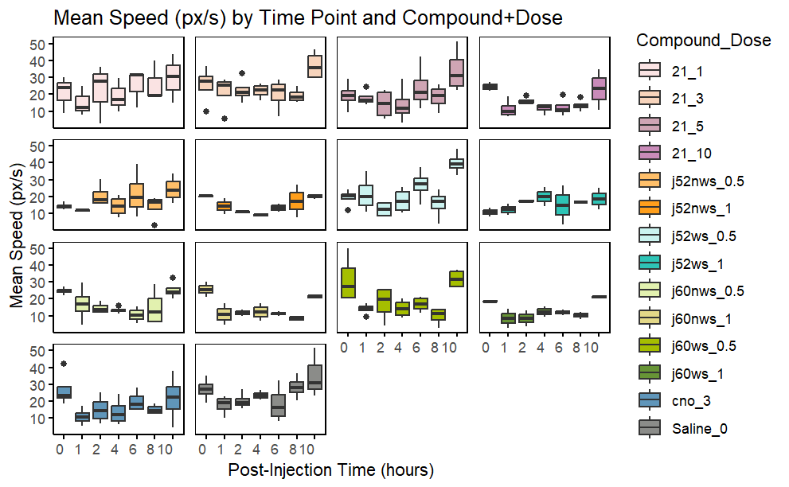

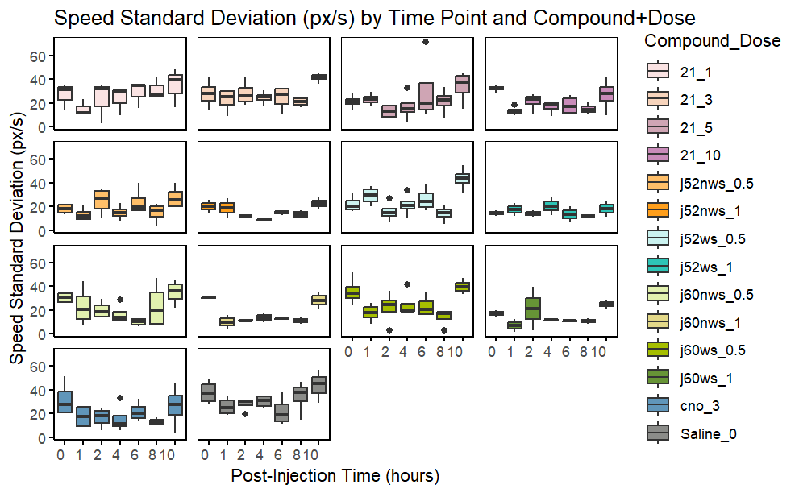

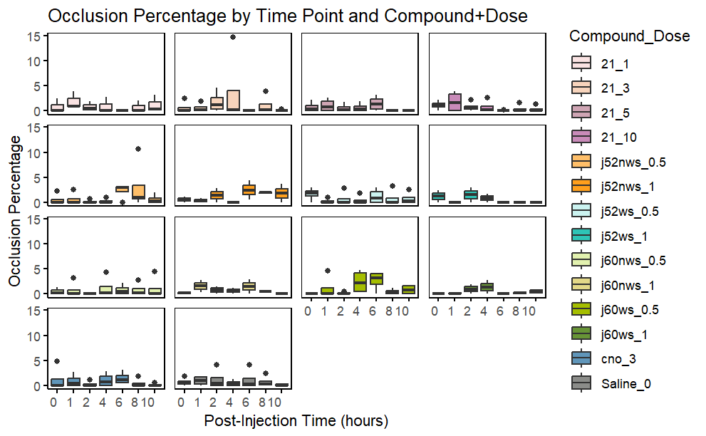

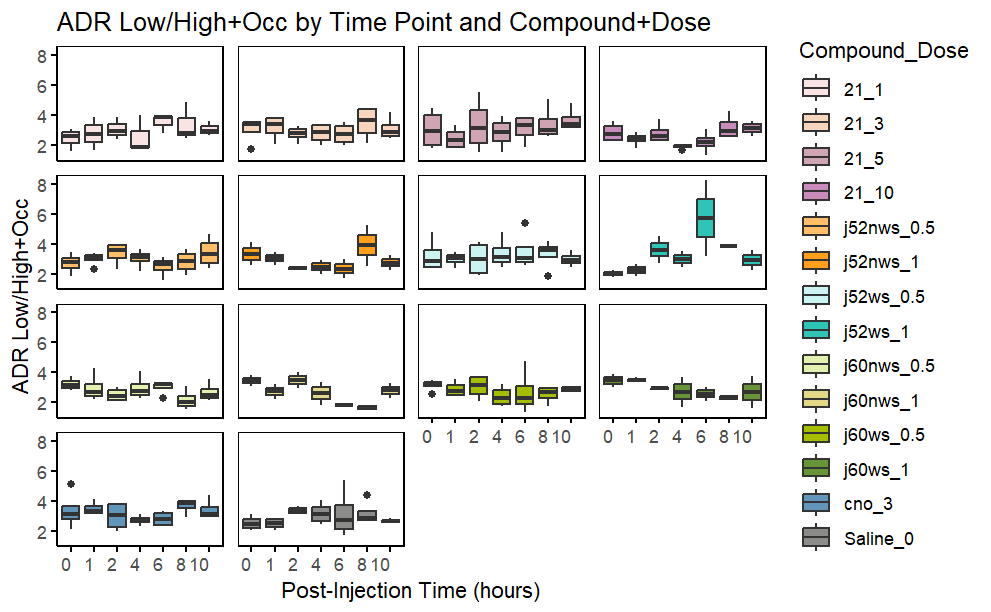

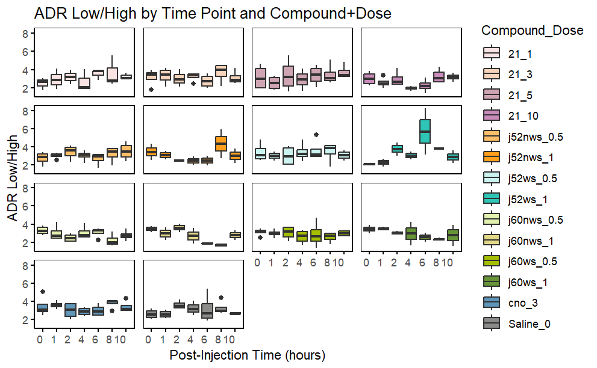

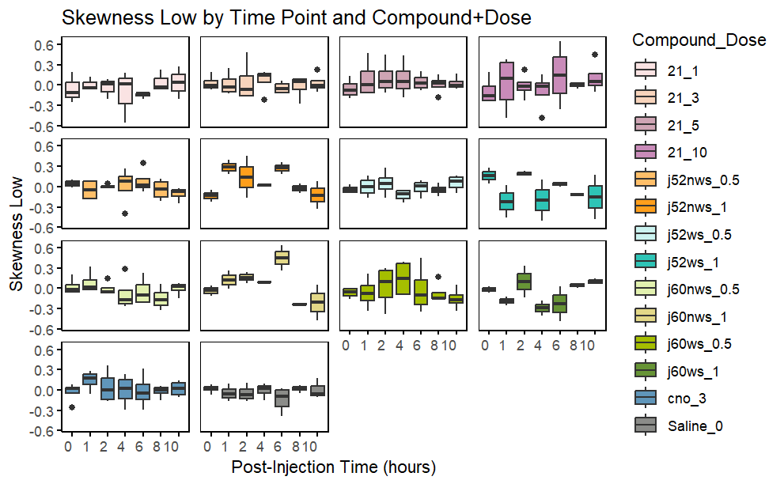

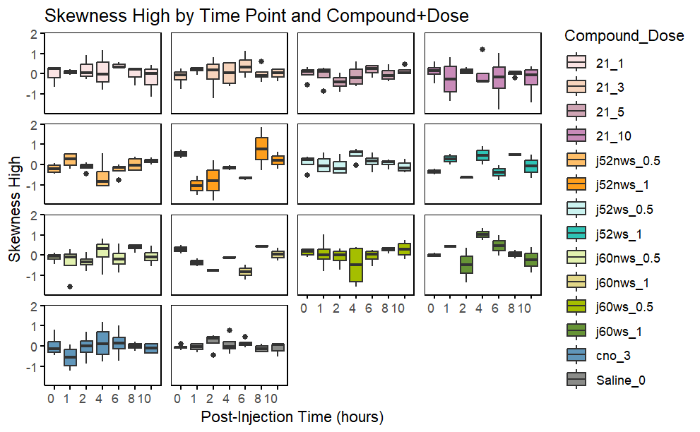

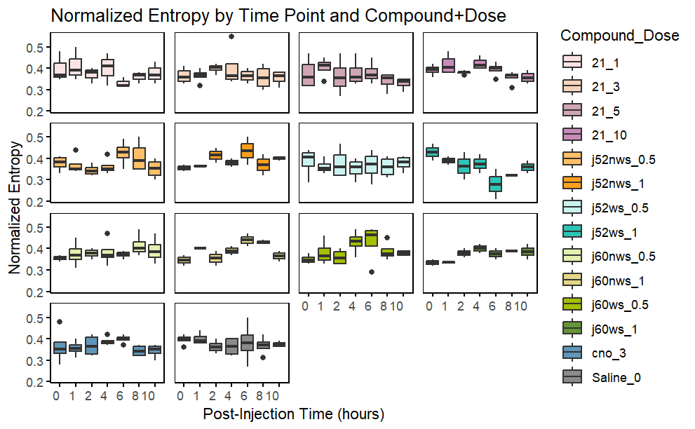

#### 2.2 Assess Baseline homogeneity

Assessing baseline homogeneity to help me decide if (1) I use baseline as a co variate in my models (controling for individual diferences at the start of the study) or (2) if I normalize the data to Baseline (focus on relative changes and eventually reduce variability).

–> I decided to take it as covariate because in some cases normalization is not possible (baseline values are 0 –> result INF) and I dont want to exclude them in my analisis nor adding a small constant to the baseline values to avoid division by 0.

```
High.activity.percentage : baseline is homogenous across the different groups (p-value > 0.05).

Low.activity.percentage : baseline is homogenous across the different groups (p-value > 0.05).

Occlusion.percentage : baseline is homogenous across the different groups (p-value > 0.05).

Mean : baseline is homogenous across the different groups (p-value > 0.05).

Std.deviation : baseline is NOT homogenous across the different groups (p-value <= 0.05).

ADR.Low.High.Occ : baseline is homogenous across the different groups (p-value > 0.05).

ADR.Low.High : baseline is homogenous across the different groups (p-value > 0.05).

skewness_low : baseline is homogenous across the different groups (p-value > 0.05).

skewness_high : baseline is homogenous across the different groups (p-value > 0.05).

normalized.entropy : baseline is homogenous across the different groups (p-value > 0.05).
```

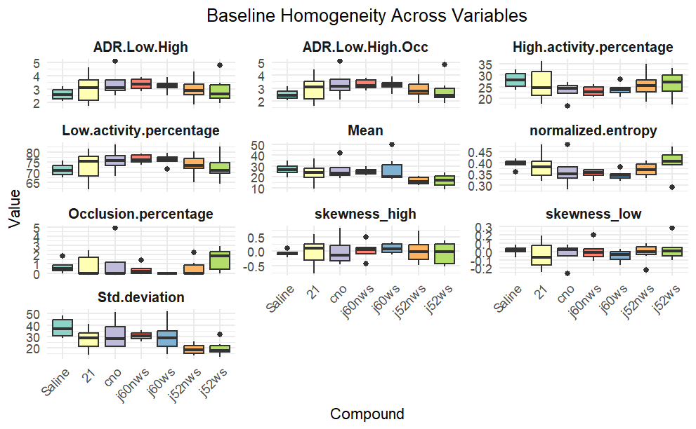

#### 2.3 Normality test

**Check normality of the response variables:**

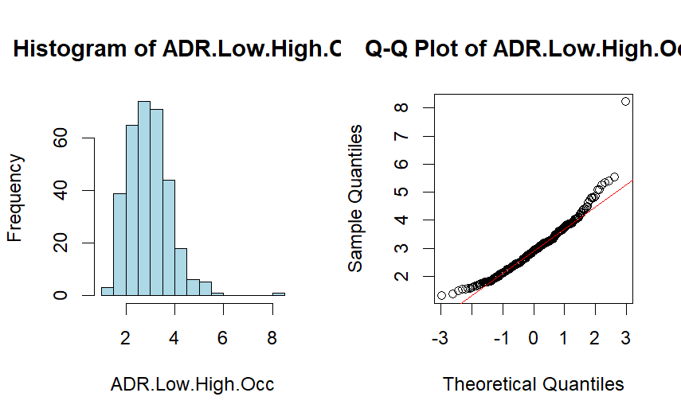

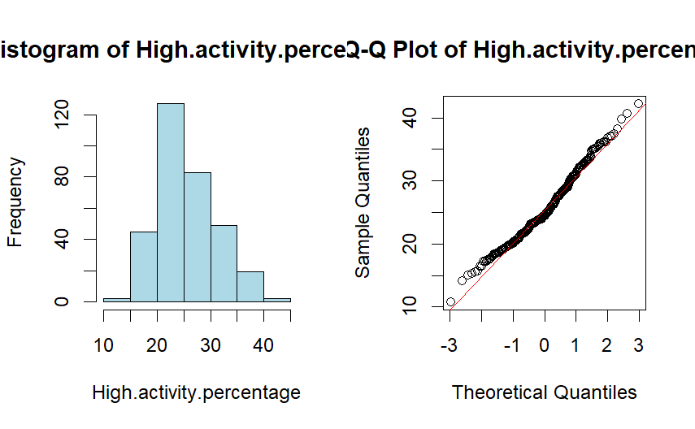

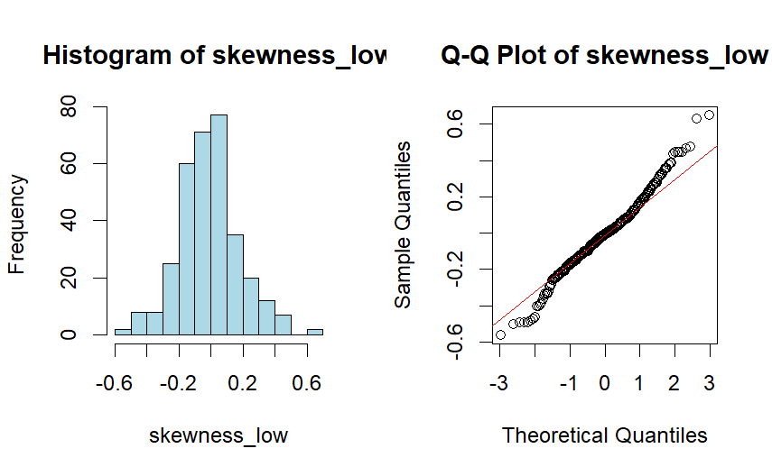

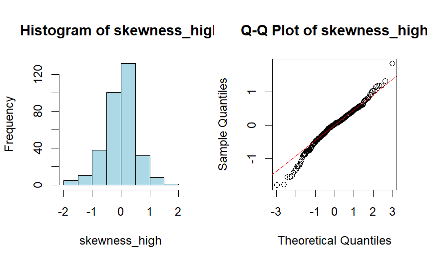

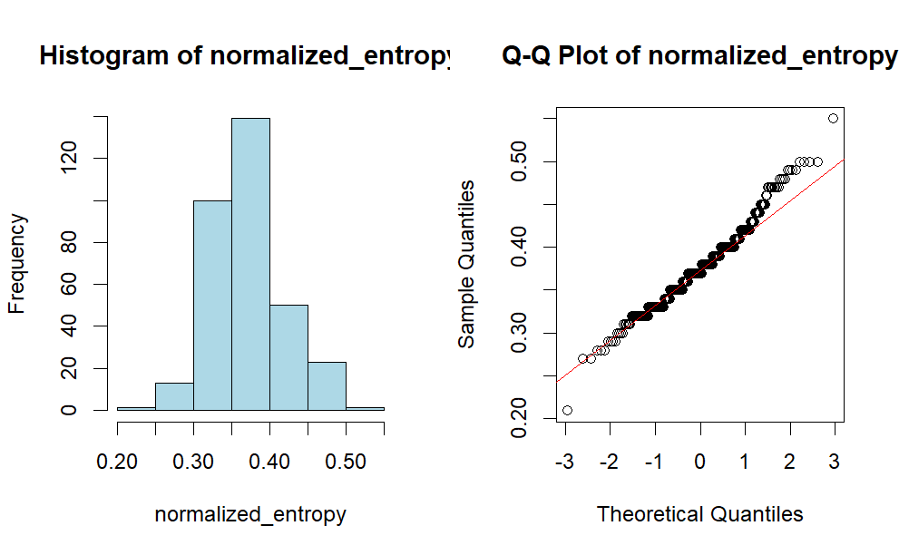

```
[1] "ADR.Low.High.Occ : Not normally distributed (p-value = 0 )"
[1] "High.activity.percentage : Not normally distributed (p-value = 0 )"
[1] "skewness_low : Not normally distributed (p-value = 0.002 )"
[1] "skewness_high : Not normally distributed (p-value = 0 )"
[1] "normalized.entropy : Not normally distributed (p-value = 0 )"
```

# III. Identify variables

## Dependent Variables (response variable)

These are the selected dependent variable, shown to be continuous and non-normally distributed as shown by the Sharpiro test .

1. ADR.Low.High.Occ
2. High Activity (%)
3. Skewness Low
4. Skewness High
5. Normalized Entropy

## Random effects and repeated measures

- **Subject ID (Categorical)**: Each subject’s unique variability is accounted for as a random effect. Plus, we do not have a large diverse sample to not consider the subject-specific variability as not relevant.
- Because the subjects are observed at different time points in a day, therefore the measurements are not independent (they are from the same subject), the subject needs to be modeled as a random effect to account for the correlation between these repeated measurements

**Unbalanced Data:** Beacause each compound does not have the same number or types of doses.

**Interaction effects**: Explore interactions between compound_dose and time post-injection since the compound effect may vary depending on this.

# IV. Selection of dependent variables

A correlation matrix and PCA biplot are nice tools for selecting the variables that are most suitable for our research question, but that also that maximize relevance, while minimizing multicollinearity and redundancy.

## Correlation matrix

**Reminders:**

- A correlation matrix ensures that your chosen dependent variables are not redundant or highly correlated with each other, leading to better model selection and performance.
- Correlation close to +1 means there is a strong positive correlation between the two variables, this suggests that the two variables move in the same direction.

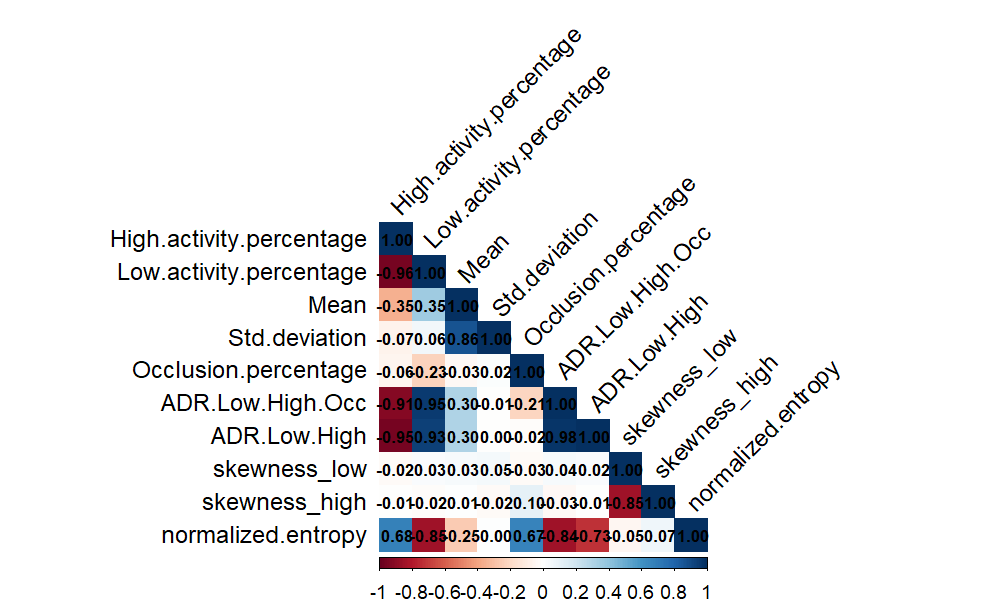

**Main results and their interpretation:**

**High** Strong positive linear relationship:

- **Std.deviation and Mean**: the average speed of the subject increases, the variability in their speed also increases suggesting that subjects that are moving faster on average tend to have more variability in their speed, indicating that higher speed is associated with more erratic or varied movement patterns.
- **ADR Low/High+Occlusion and Low activity percentage**: the percentage of time spent in low activity increases, the ratio of low activity to other states also increases. *What This Means:* When subjects spend more time in low activity, it significantly dominates their behavior relative to periods of high activity and times when they are not trackable. –> Not a surprise, maybe use one metrics only for the stats.
- **ADR Low/High and Low activity percentage:** the percentage of time spent in low activity increases, the ratio of low to high activity also increases. *What This Means*: Subjects that spend more time in low activity have a much greater proportion of low activity compared to high activity, reinforcing the idea that certain compounds might be reducing overall activity levels.–> Not a surprise, maybe use one metrics only for the stats.
- **ADR Low/High and Low and ADR Low/High+Occlusion:** as the ratio of low to high activity increases, so does the ratio of low activity to the combination of high activity and occlusion. *What this means:* This correlation indicates that the dominance of low activity is consistent whether considering just high activity or including periods of occlusion. It reinforces that subjects with higher low activity tend to have lower periods of high activity, regardless of occlusion.–> Not a surprise, maybe use one metrics only for the anova.

**Moderate** positive linear relationship:

- **Normalized entropy and Occlusion percentage**: Higher occlusion rates, where the subject’s movement cannot be tracked, lead to a more unpredictable and evenly distributed activity state. This could indicate that occlusion introduces uncertainty in tracking, leading to higher entropy values. –> Not a surprise, videos with occlusion > 20% have been identified and shifted to windows with less occlusion (most videos have between 0 - 5%).
- **Normalized entropy and High activity**: Subjects with more high activity time also exhibit more variability and transitions between activity states (i.e., they switch more frequently between high and low activity or occlusion states).

**General conclusion:** The analysis reveals that subjects with higher average speeds exhibit more variable movement patterns, suggesting that increased activity often leads to more erratic behavior. Additionally, higher low activity percentages correlate strongly with higher ratios of low activity to other states. To avoid multicollinearity and focus on the most informative metrics, I would suggest to concentrate on the **`ADR Low/High + Occlusion`** metric in further analyses, and exclude redundant metrics like `ADR Low/High`, and `Low activity percentage`

## PCA Biplot

**Reminder:** This is a useful analysis to:

1. Identify which metrics are most influential in explaining the variance in my data.
2. Reduce dimensionality: How many metrics I need to consider (the first principal components)?. These are the ones I should focus, and ignore the others, to simplify my analysis.
3. Are there distinct groups of observations? The positions of the points (scores) can reveal if there are natural groupings of your subjects or experiments. This might suggest that certain compounds or doses lead to similar activity patterns.

```
Importance of components:
                          PC1    PC2    PC3    PC4     PC5     PC6     PC7
Standard deviation     1.7041 1.3596 1.1045 0.9011 0.38584 0.21729 0.14034
Proportion of Variance 0.4148 0.2641 0.1743 0.1160 0.02127 0.00674 0.00281
Cumulative Proportion  0.4148 0.6789 0.8532 0.9692 0.99044 0.99719 1.00000
```

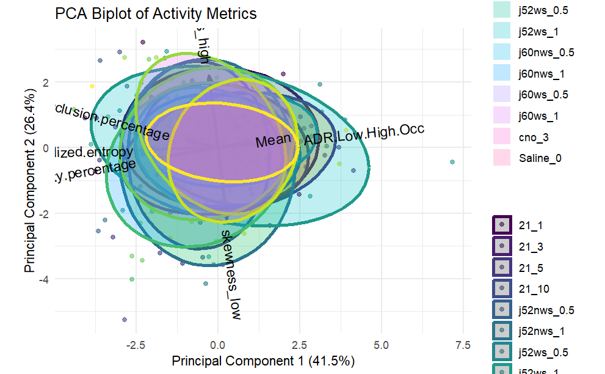

```
                                 PC1         PC2
High.activity.percentage -0.50183954 -0.10840010
Mean                      0.25916377  0.05333202
Occlusion.percentage     -0.24866364  0.08212264
ADR.Low.High.Occ          0.55526088  0.07233917
skewness_low              0.06875959 -0.69421303
skewness_high            -0.06932024  0.70090279
normalized.entropy       -0.54891692 -0.01521755
Metrics contributing most to PC1:
[1] "ADR.Low.High.Occ"         "normalized.entropy"       "High.activity.percentage"

Metrics contributing most to PC2:
[1] "skewness_high"            "skewness_low"             "High.activity.percentage"
```

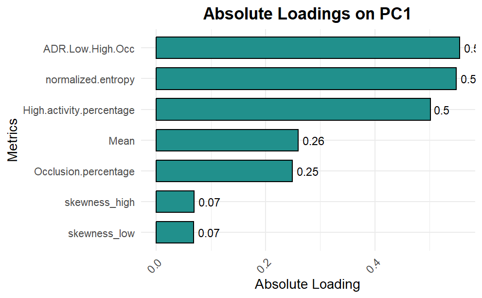

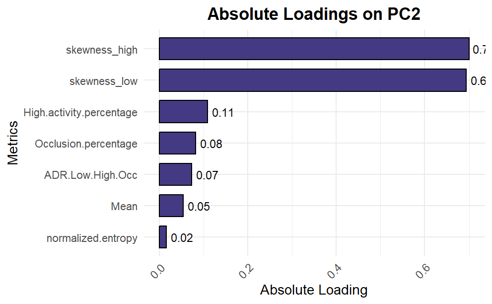

**Main results and their interpretation:**

- **Arrows (Loadings):** Metrics with longer arrows are more influential. Metrics pointing in the same direction are positively correlated. Mean speed seems to not be influential –> Remove it.
- **Points (Scores):** Clustering of points indicates that those observations have similar patterns. In this case no clear cluster appear in the data.

**General conclusion: Prioritizing Metrics:** Key metrics to prioritize based on PCA:

- **ADR.Low.High.Occ:** Captures the balance between low and high activity and contributes significantly to explaining the variance in the data.
- **High activity (%):** Indicates periods of significant movement, and its negative relationship with PC1 suggests it could reflect a different behavioral pattern than ADR.
- **Normalized entropy:** Reflects the unpredictability or randomness in activity states, contributing meaningfully to PC1.
- **Skewness low and Skewness high:** Important for understanding the timing of activity, particularly if we are interested in when during the experiment certain activities (high or low) occur.

Secondary metrics that we will not consider for this analysis (to simplify):

- Mean (px/s): This metric didn’t contribute as strongly to PC1 or PC2, but it could still be useful as a general indicator of movement.
- Occlusion (%): Its contribution to both components is relatively low, so it might not be as crucial unless you have specific concerns about data quality due to tracking issues.